# An analysis of woodland engagement and socio-demographic profile in Wale’s People and Nature Survey (2020/21)

Programme 3: Societal benefits of trees, woods and forests

Author

Daniel Braby

Published

19 May 2025

# Methodology

## Study design and sample

Data were from year 2 of the [People and Nature Survey](https://beta.ukdataservice.ac.uk/datacatalogue/series/series?id=2000125) (PANS) for Wales (Natural Resources Wales, 2022). PANS is a nationally representative omnibus survey commissioned by Natural Resources Wales which gathers information on people’s engagement, understanding and attitude towards the natural environment. Data were collected online (by Kantar). The survey builds on the Monitor of Engagement with the Natural Environment (MENE) survey which ran from 2009 to 2019.

## Data

The following socio-demographic characteristics were controlled for in the analysis: age, education (level of highest qualification), employment status, ethnicity, Index of Multiple Deprivation (IMD) decile and income. Socio-demographic characteristics are summarised in Table 1.

#### Table 1: Breakdown of socio-demographic profile

| Socio-demographic characteristic | Did not visit wooland in last month | Visited woodland in last month | NA |
| --- | --- | --- | --- |
| 16-24 | 328 (9%) | 187 (9%) | 7 (3%) |
| 25-39 | 813 (23%) | 664 (31%) | 34 (14%) |
| 40-54 | 813 (23%) | 525 (25%) | 47 (20%) |
| 55-64 | 760 (21%) | 368 (17%) | 59 (25%) |
| 65+ | 854 (24%) | 374 (18%) | 88 (37%) |

| Socio-demographic characteristic | Did not visit wooland in last month | Visited woodland in last month | NA |
| --- | --- | --- | --- |
| A university degree (or above) | 1217 (34%) | 821 (39%) | 58 (25%) |
| Any other qualifications (e.g. A Levels, O Levels, GCSEs, BTEC, Diplomas, Trade Apprenticeships) | 2090 (59%) | 1216 (57%) | 130 (55%) |
| No qualifications | 261 (7%) | 81 (4%) | 47 (20%) |

| Socio-demographic characteristic | Did not visit wooland in last month | Visited woodland in last month | NA |
| --- | --- | --- | --- |
| £0–14,999 | 703 (20%) | 312 (15%) | 99 (42%) |
| £15,000–19,999 | 516 (14%) | 255 (12%) | 34 (14%) |
| £20,000–29,999 | 790 (22%) | 482 (23%) | 40 (17%) |
| £30,000–39,999 | 540 (15%) | 331 (16%) | 20 (9%) |
| £40,000–49,999 | 367 (10%) | 266 (13%) | 19 (8%) |
| £50,000–59,999 | 229 (6%) | 179 (8%) | 9 (4%) |
| £60,000–79,999 | 216 (6%) | 141 (7%) | 8 (3%) |
| £80,000–99,999 | 86 (2%) | 90 (4%) | 2 (1%) |
| £100,000-£149,999 | 74 (2%) | 47 (2%) | 1 (0%) |
| £150,000 + | 47 (1%) | 15 (1%) | 3 (1%) |

| Socio-demographic characteristic | Did not visit wooland in last month | Visited woodland in last month | NA |
| --- | --- | --- | --- |
| 1 | 290 (8%) | 134 (6%) | 27 (11%) |
| 2 | 319 (9%) | 174 (8%) | 28 (12%) |
| 3 | 315 (9%) | 161 (8%) | 25 (11%) |
| 4 | 346 (10%) | 146 (7%) | 22 (9%) |
| 5 | 321 (9%) | 214 (10%) | 15 (6%) |
| 6 | 288 (8%) | 192 (9%) | 14 (6%) |
| 7 | 240 (7%) | 194 (9%) | 21 (9%) |
| 8 | 227 (6%) | 193 (9%) | 15 (6%) |
| 9 | 294 (8%) | 189 (9%) | 11 (5%) |
| 10 | 288 (8%) | 213 (10%) | 9 (4%) |
| NA | 640 (18%) | 308 (15%) | 48 (20%) |

| Socio-demographic characteristic | Did not visit wooland in last month | Visited woodland in last month | NA |
| --- | --- | --- | --- |
| Any other ethnic group or background | 17 (0%) | 10 (0%) | 2 (1%) |
| Asian or Asian British | 114 (3%) | 18 (1%) | 4 (2%) |
| Black or Black British | 43 (1%) | 9 (0%) | 0 (0%) |
| Mixed | 77 (2%) | 34 (2%) | 7 (3%) |
| White | 3236 (91%) | 2012 (95%) | 209 (89%) |
| NA | 81 (2%) | 35 (2%) | 13 (6%) |

Analyses were conducted in R 4.2.1 (R Core Team, 2022). We used generalised linear modelling to investigate the association between woodland engagement (dependent/response variable) and socio-demographic profile (independent variables/predictors).

Significant socio-demographic characteristics were identified based on Analysis of Variance (ANOVA) using likelihood ratio chi-squared statistics (Fox & Weisberg, 2019). Estimated marginal means for each socio-demographic characteristic were estimated post-hoc using the `ggemmeans()` function in the `{ggeffects}` package (Lüdecke, 2018). Model fit statistics (AIC, $w_i$, Tjur’s $R^2$) were calculated using the `{performance}` package (Lüdecke, 2021).

# Results

Findings Summary

The logistic regression model examines the likelihood of a respondent visiting a woodland in the last month (Y = 1) based on socio-demographic and geographic predictors. Key findings are summarized below:

⸻

⸻

Insignificant Predictors • Income bands below £20,000 and above £100,000-£149,999 showed no significant impact. • Some geographic IMD deciles (e.g., 2, 3, 4) and the qualifications category “Any other qualifications” were not statistically significant.

⸻

Model Fit • Residual Deviance: 6015.6 (improved from null deviance of 6260.6, indicating the model explains some variance). • AIC: 6073.6 (acceptable fit). • Significant Predictors Count: Several predictors across demographics, income, area deprivation, and ethnicity were meaningful contributors.

⸻

Conclusion

The likelihood of visiting a woodland is influenced by a combination of socio-demographic factors (age, income, ethnicity, qualifications) and geographic characteristics (area deprivation). Middle-income groups, less deprived areas, and certain age bands (young adults) are more likely to visit, while older adults, less qualified individuals, and certain ethnic minorities are less likely to participate. These insights can inform targeted outreach or policy interventions to encourage more equitable woodland engagement.

#### Figure 1: Estimated marginal means for woodland engagement by age

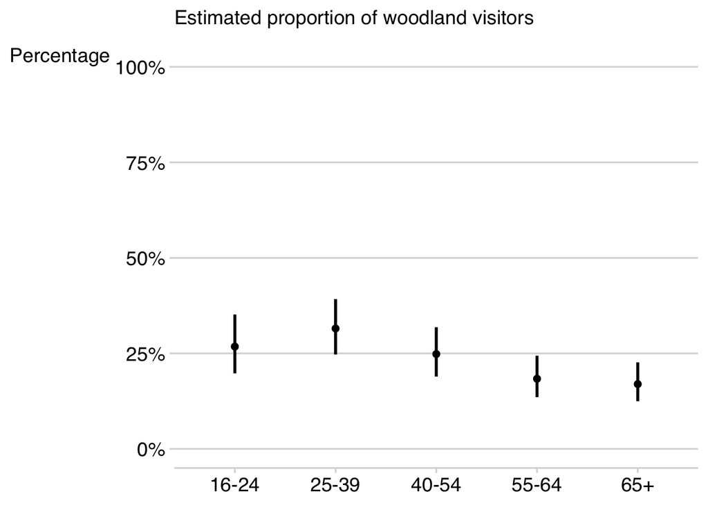

#### Figure 2: Estimated marginal means for woodland engagement by income

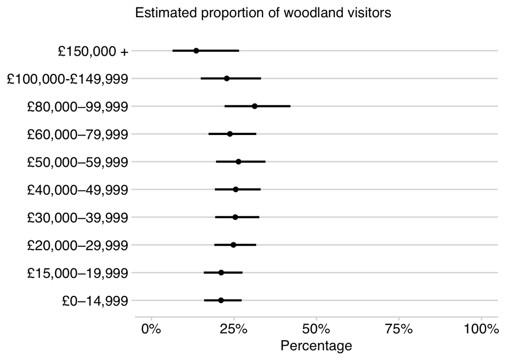

#### Figure 3: Estimated marginal means for woodland engagement by home Index of Multiple Deprivation (IMD) decile

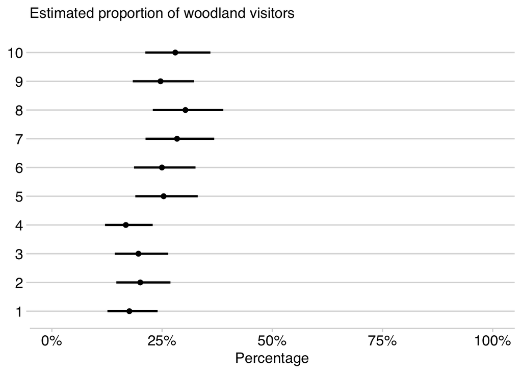

#### Figure 4: Estimated marginal means for woodland engagement by ethnicity

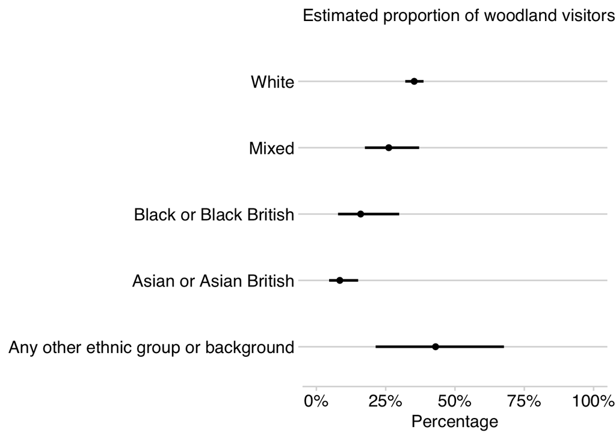